# Practical Machine Learning Project

## Background

Using devices such as Jawbone Up, Nike FuelBand, and Fitbit it is now possible to collect a large amount of data about personal activity relatively inexpensively. In this project, the goal will be to use data from accelerometers on the belt, forearm, arm, and dumbell of 6 participants. They were asked to perform barbell lifts correctly and incorrectly in 5 different ways. The goal of this project is to predict the manner in which they did the exercise.

## Read in Data and Perform EDA

All packages needed to perform the analysis were loaded and then the datasets of interest were read in. Missing value treatment was performed.

```r
library(caret)
library(randomForest)
train = read.csv("C:/Users/jane.s.turnbull/Documents/R/Practical Machine Learning/pml-training.csv",na.strings=c("NA","#DIV/0!", ""))
test = read.csv("C:/Users/jane.s.turnbull/Documents/R/Practical Machine Learning/pml-testing.csv",na.strings=c("NA","#DIV/0!", ""))
```

A quick check of the dependent variable using the summary function is run. The first 7 variables of the training data set were eliminated as they did not appear to be necessary to any type of prediction. A seed was set to ensure reproducibility of results.

```r
summary(train$classe)
```

```
##    A    B    C    D    E
## 5580 3797 3422 3216 3607
```

```r
train <- subset(train, select=-c(1:7))
set.seed(573287)
```

The Train data set was randomly split into two datasets, Training and Validation. The Training data set contains 60% of the observations and the Validation data set contains 40% of the observations. The dependent variable Classe was then plotted to see its distribuion on the Training data set.

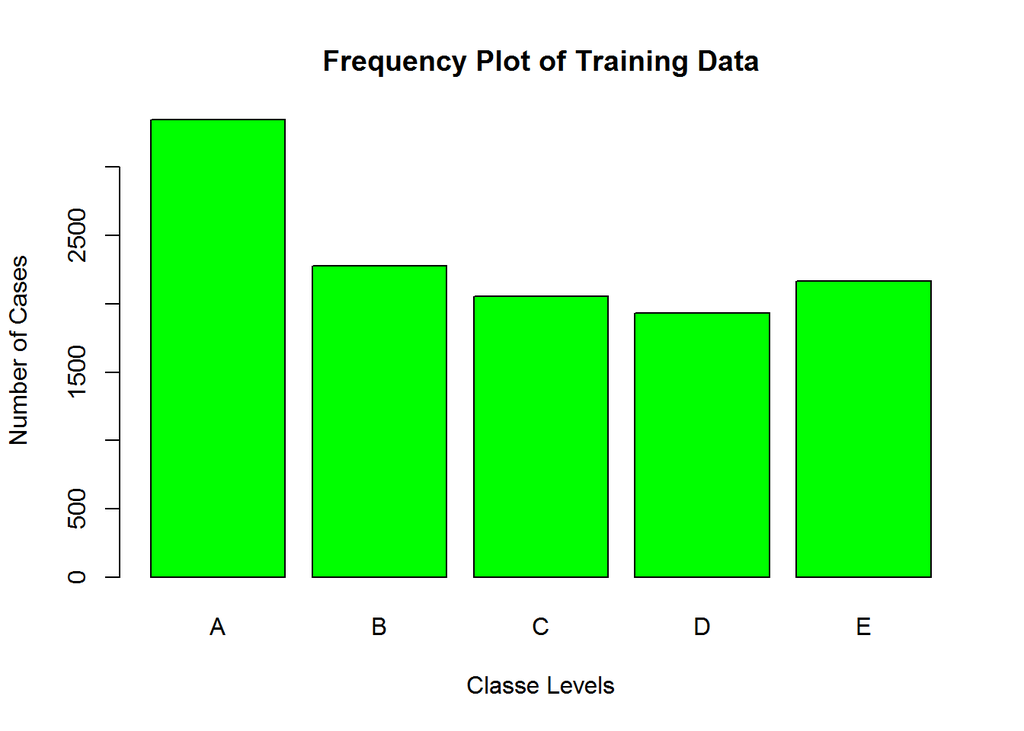

```r
intrain <- createDataPartition(train$classe, p = 0.6, list = FALSE)
Training <- train[intrain, ]
Validation <- train[-intrain, ]

plot(Training$classe,col="green",main="Frequency Plot of Training Data",xlab="Classe Levels",
     ylab="Number of Cases")
```

It was noticed that many of the variables on the Training data set had many missing values. To reduce the number of variables being introduced into the analysis, it was decided to eliminate variables that were missing 95% of the time or more.

```r
missing_value<-0.95*dim(Training)
keep_cols <- !apply(Training, 2, function(y) sum(is.na(y)) > missing_value || sum(y=="") > missing_value)
Training <- Training[, keep_cols]
```

## Random Forest Results

The random forest technique was applied to the Training data set and prediction results were generated for the Validation data sets. The accuracy of the prediction on the Validation data set was 0.9951568, and then the algorithm was run on the test sample of 20 observations. The results are shown below.

```r
model_tree <- randomForest(classe~., data=Training, importance=TRUE)
model_tree
```

```
##
## Call:
##  randomForest(formula = classe ~ ., data = Training, importance = TRUE)
##                Type of random forest: classification
##                      Number of trees: 500
## No. of variables tried at each split: 7
##
##         OOB estimate of  error rate: 0.61%
## Confusion matrix:
##      A    B    C    D    E  class.error
## A 3345    2    0    0    1 0.0008960573
## B   13 2263    3    0    0 0.0070206231
## C    0   14 2036    4    0 0.0087633885
## D    0    0   25 1902    3 0.0145077720
## E    0    0    2    5 2158 0.0032332564
```

```r
pred_tree = predict(model_tree, Validation)
tree_accuracy = sum(pred_tree == Validation$classe) / length(pred_tree)
tree_accuracy
```

```
## [1] 0.9951568
```

```r
pred_tree_test = predict(model_tree, test)
pred_tree_test
```

```
##  1  2  3  4  5  6  7  8  9 10 11 12 13 14 15 16 17 18 19 20
##  B  A  B  A  A  E  D  B  A  A  B  C  B  A  E  E  A  B  B  B
## Levels: A B C D E
```

## Linear Discriminant Analysis Results

The linear discriminant analysis technique was applied to the Training data set and prediction results were generated for the Validation data sets. The accuracy of the prediction on the Validation data set was 0.708259, and then the algorithm was run on the test sample of 20 observations. The results are shown below. This method did not perform as well as random forest.

```r
model_lda <-train(classe ~ ., method = 'lda', data = Training)
model_lda
```

```
## Linear Discriminant Analysis
##
## 11776 samples
##    52 predictor
##     5 classes: 'A', 'B', 'C', 'D', 'E'
##
## No pre-processing
## Resampling: Bootstrapped (25 reps)
##
## Summary of sample sizes: 11776, 11776, 11776, 11776, 11776, 11776, ...
##
## Resampling results
##
##   Accuracy   Kappa      Accuracy SD  Kappa SD
##   0.6964078  0.6159996  0.005929526  0.00738314
##
##
```

```r
pred_lda = predict(model_lda, Validation)
lda_accuracy = sum(pred_lda == Validation$classe) / length(pred_lda)
lda_accuracy
```

```
## [1] 0.708259
```

```r
pred_lda_test = predict(model_lda, test)
pred_lda_test
```

```
##  [1] B A B C C E D D A A D A B A E A A B B B
## Levels: A B C D E
```